# Using the GOFmeasure function

Ilaria Prosdocimi and Thomas Kjeldsen

2020-07-16

The main function found in the `GOFmeas` package is `GOFmeasure`, which computes the Goodness of fit measure for a regional flood frequency analysis as proposed by Hosking and Wallis (1997)[^1] and the bivariate extension proposed by Kjeldsen and Prosdocimi (2015)[^2] .

All that is needed to build the goodness of fit measure is the sample L-moments for each site that is part of the regions and the sample size information for each site. Given the different way data could be stored, two ways to input these information are allowed: either via the `stations` argument or via the combined `lmom` and `n.amax` arguments. If the `stations` argument is used that the input should be a list in which each component is the annual maxima sample for a station: the L-moments matrix and the sample sizes will be extracted directly. If the `lmom` and `n.amax` arguments are used `lmom` should be a matrix of sample L-moments (typically the result of a `lmom::samlmu` call) with one line for each station and at least the first 4 sample L-moments and `n.amax` should be a vector of size `nrow(lmom)` with information on the sample size of each station.

Below is an example of how to use the `GOFmeasure` function with some synthetic data.

```r
library(GOFmeas)
library(lmom)
set.seed(154)
# generate a region with (mostly) GEV distribution
# this is a list
stats <- list(quagev(runif(30,0,1),c(289, 45 ,-0.22)),
              quagev(runif(45,0,1),c(189, 40 ,-0.15)),
              quagev(runif(25,0,1),c(122, 10 ,-0.24)),
              quagev(runif(43,0,1),c( 59,  8 ,-0.18)),
              quagev(runif(32,0,1),c( 62, 10 ,-0.21)),
              quagev(runif(28,0,1),c( 91,  9 ,-0.25)),
              quaglo(runif(27,0,1),c(202, 25 ,-0.17)))
set.seed(15544) # needed to ensure the results are always the same
tt <- GOFmeasures(stats)
class(tt) # the GOFmeas class
##  [1] "GOFmeas"
# print and summary available for the GOFmeas class
tt
##            GLO     GEV     GNO     PE3
##  HW_GOF 0.7875 -0.0029 -0.5314 -1.4634
##  KP_GOF 2.2990  0.1350  0.2780  2.7978
summary(tt)
##         minvalues Distribution
##  HW_GOF    0.0029          GEV
##  KP_GOF    0.1350          GEV
```

Note that in order for the results to be always the same a `set.seed()` call is included before the `GOFmeasures` call: since the bias correction and the variance-covariance matrix of the sample L-moments are estimated via a Monte Carlo simulation if `set.seed()` is not called the results might be slightly different each time one uses `GOFmeasures`:

```r
ob1 <- GOFmeasures(stats); ob1
##            GLO     GEV    GNO     PE3
##  HW_GOF 0.7711 -0.0464 -0.593 -1.5570
##  KP_GOF 1.9726  0.0872  0.320  3.0476
ob2 <- GOFmeasures(stats); ob2
##            GLO     GEV     GNO     PE3
##  HW_GOF 0.7655 -0.0556 -0.6046 -1.5729
##  KP_GOF 1.9264  0.0598  0.3891  3.2168
```

The matrix of Monte Carlo simulations is stored in the `mcmom` object in the output, so it can be reused to obtain the same result as a previous call:

```r
head(ob1$mcmom)
##           [,1]     [,2]      [,3]      [,4]
##  [1,] 163.3221 21.11808 0.2761461 0.1674570
##  [2,] 165.5539 21.75565 0.2781262 0.1892476
##  [3,] 161.4549 19.53266 0.2755232 0.1985564
##  [4,] 164.5091 22.34705 0.2700546 0.1984392
##  [5,] 162.7619 20.87144 0.2692297 0.1815964
##  [6,] 163.8965 21.45409 0.2688101 0.2003487
GOFmeasures(stats, mcmom = tt$mcmom)
##            GLO     GEV     GNO     PE3
##  HW_GOF 0.7875 -0.0029 -0.5314 -1.4634
##  KP_GOF 2.2990  0.1350  0.2780  2.7978
```

The size of the `mcmom` matrix can be changed by using the `Nsim` argument if the `GOFmeasures` call:

```r
obj3 <- GOFmeasures(stats, Nsim = 1200)
obj3
##            GLO     GEV     GNO     PE3
##  HW_GOF 0.7802 -0.0259 -0.5648 -1.5153
##  KP_GOF 2.0859  0.0824  0.3506  3.0404
dim(obj3$mcmom)
##  [1] 1200    4
```

The use of the `plot=TRUE` argument will produce an L-moment diagram with a representation of the bivariate goodness of fit measure. Further, the use of the `conf.lev` argument would change the confidence level at which the bivariate measure rejects the candidate distributions.

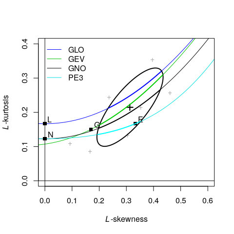

```
##            GLO     GEV     GNO     PE3
##  HW_GOF 0.3376 -0.1966 -0.5537 -1.1836
##  KP_GOF 0.8752  0.0530  0.1682  1.6016
# change the confidence level used to testing
GOFmeasures(stations = stats, mcmom = obj3$mcmom, plot = TRUE, conf.lev = 0.5)
```

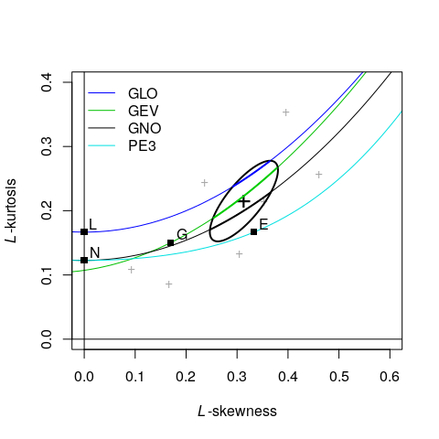

```
##            GLO     GEV     GNO     PE3
##  HW_GOF 0.3376 -0.1966 -0.5537 -1.1836
##  KP_GOF 0.8752  0.0530  0.1682      NA

# for lower levels the ellipse shrinks: less distributions accepted
```

```r
GOFmeasures(stations = stats, mcmom = obj3$mcmom, plot = TRUE, conf.lev = 0.9)
```

[output not shown]

The example above shows that if no set of theoretical L-moments of a distribution lay within the `conf.lev` ellipse for the L-skewness and L-kurtosis, the distribution is deemed non-acceptable for the Kjeldsen and Prosdocimi (KP) measure and an `NA` value appears.

If only the Hosking and Wallis or only the Kjeldsen and Prosdocimi goodness of fit measure is needed, the `type` argument should be used:

```r
# only the HW measure
GOFmeasures(stations = stats, type="HW_GOF", mcmom = obj3$mcmom)
##      GLO     GEV     GNO     PE3
##   0.3376 -0.1966 -0.5537 -1.1836
# only the KP measure
GOFmeasures(stations = stats, type="KP_GOF", mcmom = obj3$mcmom)
##     GLO    GEV    GNO    PE3
##  0.8752 0.0530 0.1682 1.6016
```

Finally, below an example of how to pass on `GOFmeasures` information on the stations using the `lmom` and `n.amax` arguments:

```r
ll <- do.call(rbind,lapply(stats,samlmu)) ## L-moments matrix
ss <- unlist(lapply(stats,length))  ## sample size vector
GOFmeasures(lmom=ll, n.amax = ss)
##            GLO     GEV     GNO     PE3
##  HW_GOF 0.7688 -0.0571 -0.6093 -1.5832
##  KP_GOF 2.1936  0.0765  0.4143  3.3250
```

[^1]: Hosking, J. R. M., and J. R. Wallis (1997), Regional frequency analysis: an approach based on L-moments, Cambridge University Press
[^2]: Kjeldsen T. R. and Prosdocimi I. (2015) A bivariate extension of the Hosking and Wallis goodness-of-fit measure for regional distributions. Water Resources Research. [DOI: 10.1002/2014WR015912](http://onlinelibrary.wiley.com/doi/10.1002/2014WR015912/abstract)